# assignment_4_blaufuss

Dennis Blaufuss

12/01/2021

##### 1. The following plot of the posterior predictions of the Chimpanzee experiment is the bottom panel of Figure 11.4 on page 333.

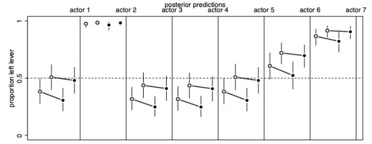

##### Adapt the code in the book for plotting the observed data (Figure 11.4, top panel) to recreate this posterior predictions plot. Your answer must include the plot and your code.

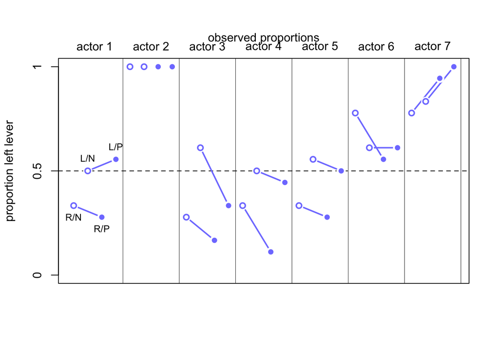

```r
data(chimpanzees)
d <- chimpanzees
d$treatment <- 1 + d$prosoc_left + 2*d$condition

dat_list <- list(
    pulled_left = d$pulled_left,
    actor = d$actor,
    treatment = as.integer(d$treatment) )

m1 <- ulam(
    alist(
        pulled_left ~ dbinom(1, p ) ,
        logit(p) <- a[actor] + b[treatment] ,
        a[actor] ~ dnorm( 0 , 1.5 ),
        b[treatment] ~ dnorm( 0 , 0.5 )
    ),
    data=dat_list,
    chains=4,
    log_lik=TRUE )

# Code given in book:
pl <- by( d$pulled_left , list( d$actor , d$treatment ) , mean )

plot( NULL , xlim=c(1,28) , ylim=c(0,1) , xlab="" ,
    ylab="proportion left lever" , xaxt="n" , yaxt="n" )
axis( 2 , at=c(0,0.5,1) , labels=c(0,0.5,1) )
abline( h=0.5 , lty=2 )
for ( j in 1:7 ) abline( v=(j-1)*4+4.5 , lwd=0.5 )
for ( j in 1:7 ) text( (j-1)*4+2.5 , 1.1 , concat("actor ",j) , xpd=TRUE )
for ( j in (1:7)[-2] ) {
    lines( (j-1)*4+c(1,3) , pl[j,c(1,3)] , lwd=2 , col=rangi2 )
    lines( (j-1)*4+c(2,4) , pl[j,c(2,4)] , lwd=2 , col=rangi2 )
}
points( 1:28 , t(pl) , pch=16 , col="white" , cex=1.7 )
points( 1:28 , t(pl) , pch=c(1,1,16,16) , col=rangi2 , lwd=2 )
yoff <- 0.01
text( 1 , pl[1,1]-yoff , "R/N" , pos=1 , cex=0.8 )
text( 2 , pl[1,2]+yoff , "L/N" , pos=3 , cex=0.8 )
text( 3 , pl[1,3]-yoff , "R/P" , pos=1 , cex=0.8 )
text( 4 , pl[1,4]+yoff , "L/P" , pos=3 , cex=0.8 )
mtext( "observed proportions\n" )
```

###### Answer:

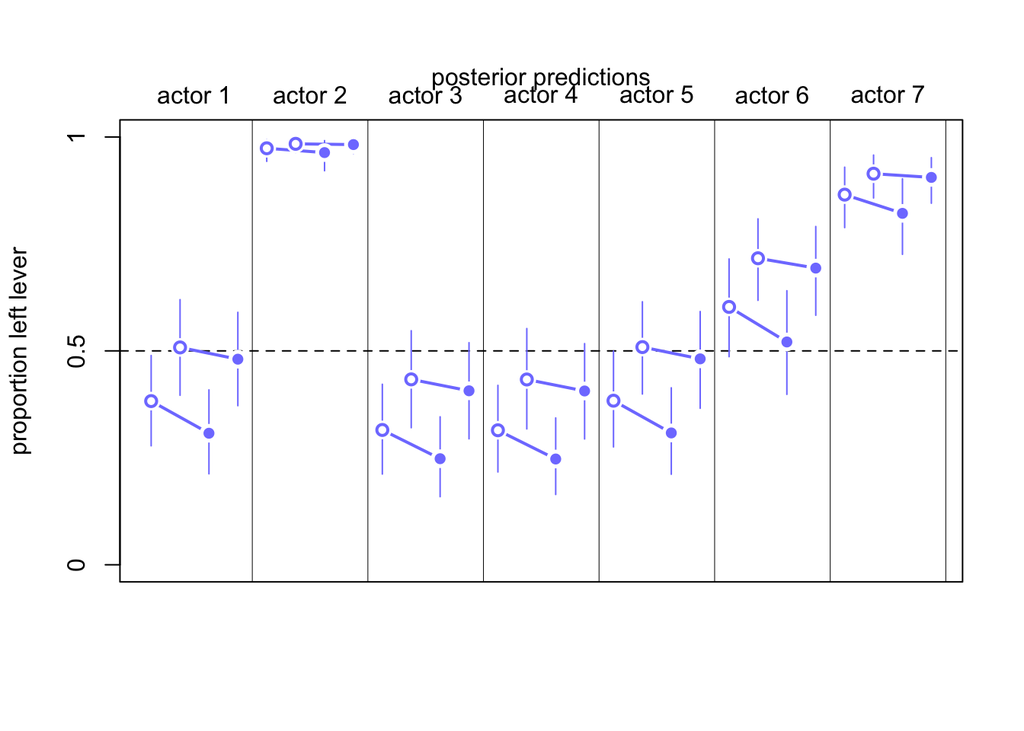

```r
dat_list2 <- list( actor=rep(1:7,each=4) , treatment=rep(1:4,times=7))
p_post <- link( m1 , data=dat_list2 )
p_mu <- apply( p_post , 2 , mean )
mu.PI <- apply( p_post , 2 , PI , prob=0.89 )
plot( NULL , xlim=c(1,28) , ylim=c(0,1) , xlab="" ,
ylab="proportion left lever" , xaxt="n" , yaxt="n" )
axis( 2 , at=c(0,0.5,1) , labels=c(0,0.5,1) )
abline( h=0.5 , lty=2 )
for ( j in 1:7 ) abline( v=(j-1)*4+4.5 , lwd=0.5 )
for ( j in 1:7 ) text( (j-1)*4+2.5 , 1.1 , concat("actor ",j) , xpd=TRUE )
for ( j in (1:7) ) {
    lines( (j-1)*4+c(1,3) , p_mu[4*(j-1)+c(1,3)] , lwd=2 , col=rangi2 )
    lines( (j-1)*4+c(2,4) , p_mu[4*(j-1)+c(2,4)] , lwd=2 , col=rangi2 )
}
for ( j in 1:28 ) lines( rep(j,2) , mu.PI[,j] , col=rangi2 )
points( 1:28 , t(p_mu) , pch=16 , col="white" , cex=1.7 )
points( 1:28 , t(p_mu) , pch=c(1,1,16,16) , col=rangi2 , lwd=2 )
yoff <- 0.01
mtext( "posterior predictions\n" )
```

##### 2. The Wines2012 data set includes expert scores given by expert American and French judges.

```r
data(Wines2012)
d <- Wines2012
precis(d)
```

|  | mean | sd | 5.5% | 94.5% | histogram |
| --- | --- | --- | --- | --- | --- |
| judge | NaN | NA | NA | NA |  |
| flight | NaN | NA | NA | NA |  |
| wine | NaN | NA | NA | NA |  |
| score | 14.2000000 | 2.6639535 | 10 | 18 | ▁▁▂▂▃▂▅▇▅▃▃▁▁ |
| wine.amer | 0.6000000 | 0.4912645 | 0 | 1 | ▅▁▁▁▁▁▁▁▁▇ |
| judge.amer | 0.5555556 | 0.4982901 | 0 | 1 | ▅▁▁▁▁▁▁▁▁▇ |

##### You should standardize and create IDs to distinguish between American and French judges and American and French wines:

```r
# standardize scores and create IDs for
# American/French judges and wines
dat_list <- list(
 S = standardize(d$score),
 jid = as.integer(d$judge),
 wid = as.integer(d$wine)
 )
```

##### Your goal is to model the score, the subjective rating assigned by each judge to each wine.

##### For this first model, you should only consider variation among judges and wines.

##### (a) Construct index variables for judge and wine and using these index variables to construct a linear regression model. You should end up with 9 judge parameters and 20 wine parameters.

##### (b) Justify the priors you use.

##### (c) Use ulam instead of quap to build this model.

##### (d) Check your chains for convergence.

##### Is there variation among individual judges and individual wines? Are there patterns you can notice just by plotting the differences? Which judges have the lowest and highest ratings? Which wines are rated worst and which best on average?

```r
m2 <- ulam(
  alist(
    S ~ dnorm(mu, sigma),
    mu <- a[jid] + b[wid],
    a[jid] ~ dnorm(0, 0.5),
    b[wid] ~ dnorm(0, 0.5),
    sigma ~dexp(1)
  ),
  data=dat_list,
  chains=4,
  cores=4)

precis(m2, 2)
```

[output not shown]

Note: I have disabled messages on this code block since with knitting it outputs an error but still the model works etc. As discussed in class briefly I guess this is due to M1. But since the model works and takes normal time to be computed I’m sure there is no issue (when running the code normally in RStudio everything works fine).

```
## [1] 1000
## [1] 1
## [1] 1000
```

```
## Waiting to draw page 2 of 2
```

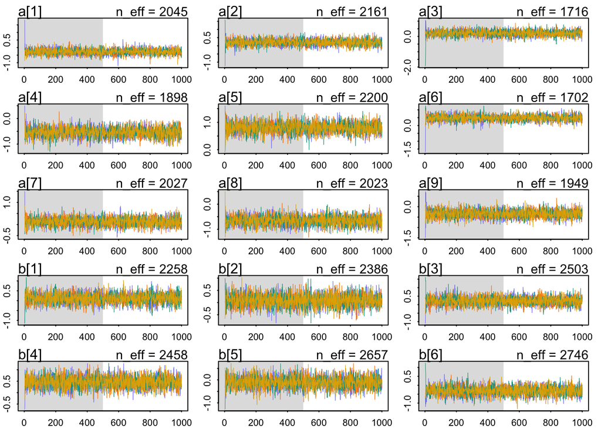

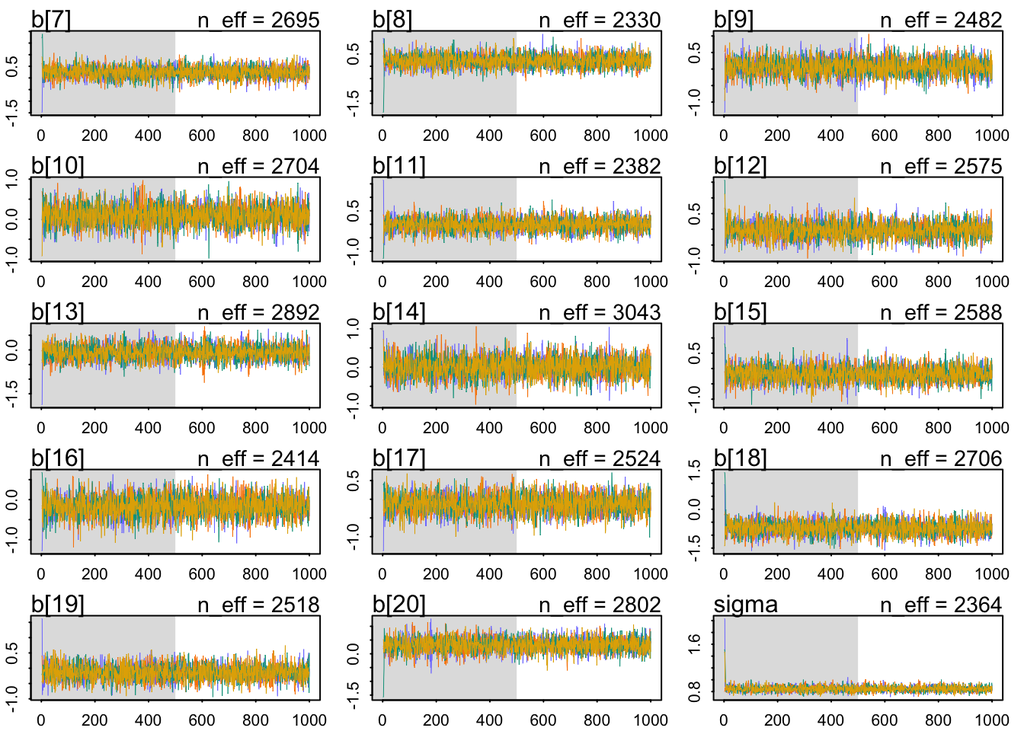

```r
traceplot(m2)
```

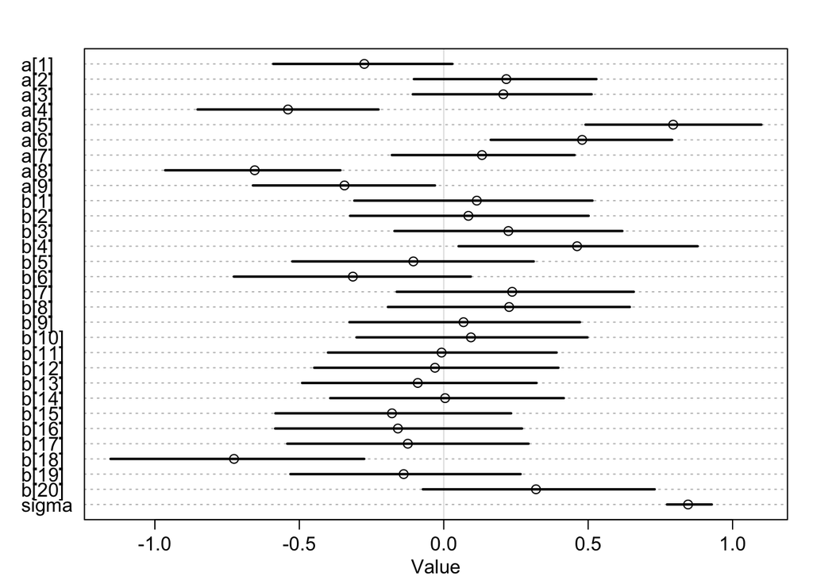

```r
plot(precis(m2, 2))
```

###### Answer:

While looking at the precis plot we can answer the question stated above: Firstly, let’s focus on the a’s, meaning the judges: We can note that Judge 8 is the harshest whilst judge 5 seems to love wine and general a lot and thus gives the best ratings. Furthermore, we see that there is a good distribution of the harshness over the span of all judges. Now, let’s have a look at the b’s and thus wines: Here we can see that the differences between all the wines aren’t that big (in comparison to the judges). Still we can note that Wine 4 is slightly the best and wine 18 appears to be pretty bad (better said best/badly rated to be exact here).

##### 3. Now consider three features of the wines and judges:

##### flight: whether the wine is red or white.

##### wine.amer: Indicator variable for American wines

##### judge.amer: Indicator variable for American judges

##### Use indicator variables to model the influence of these features on the scores.

##### Here is a line of R code to convert the flight values (strings) to integer values of an indicator:

```r
# indicator for red wine
R = ifelse(d$flight =="red", 1L, 0L)
```

**Tip:** *Note that 1L and 0L are integers, whereas 1 and 0 are real (actually, floating point) numbers. Indicator and index values should be integers.*

##### (a) Omit the individual judge and wine index variables from Problem 2.

##### (b) Do not include interaction effects.

##### (c) Use ulam, justify your priors, and check your chains.

##### What do you conclude about the differences among the wines and judges? Compare your results to the results from Problem 2.

```r
dat_list2 <- list(
    S = standardize(d$score),
    W = d$wine.amer,
    J = d$judge.amer,
    R = ifelse(d$flight == "red", 1L, 0L))

m3 <- ulam(
  alist(
    S ~ dnorm(mu, sigma),
    mu <- a + bW*W + bJ*J + bR*R,
    a ~ dnorm(0, 0.2),
    bW~ dnorm(0, 0.5),
    bJ~ dnorm(0, 0.5),
    bR~ dnorm(0, 0.5),
    sigma ~ dexp(1)
    ),
  data=dat_list2,
  chains=4 ,
  cores=4)

precis(m3)
```

[output not shown]

Same note as for previous model applies.

```
## [1] 1000
## [1] 1
## [1] 1000
```

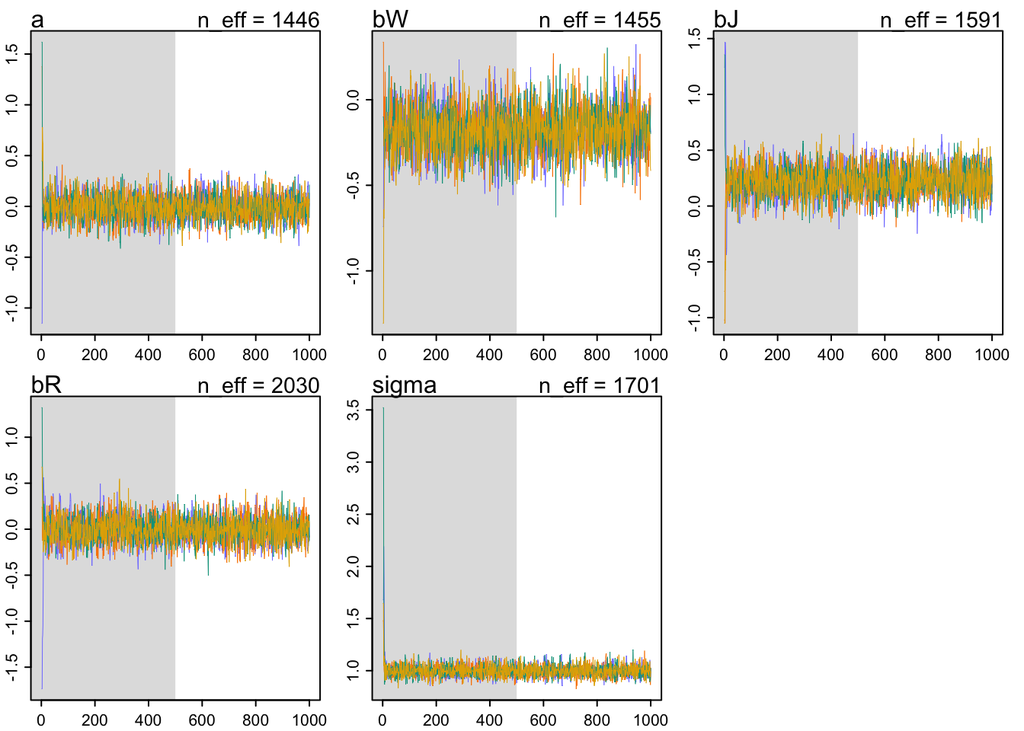

```r
traceplot(m3)
```

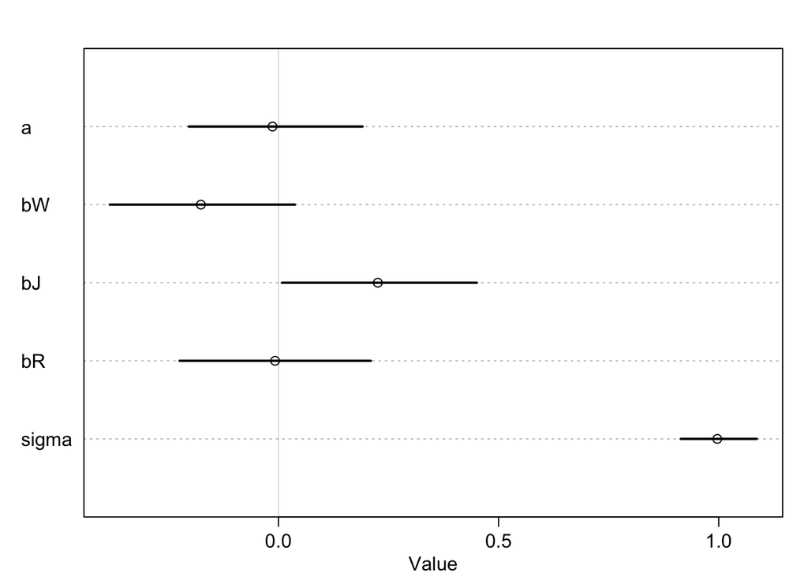

```r
plot(precis(m3, 2))
```

###### Answer:

To answer the question above refer to the precis function output:

- The flight of the wine (meaning it being red or white) does not seem to have any impact on the rating on average (bR is around zero).
- The not American judges (thus french ones) seem to be the harsher ones (bJ above zero).
- The American wines seem to perform worse than the not American wines on average (bW below zero).

Since we take two different point of views in the two problems a direct comparison is difficult. I think whats worth mentioning here is: In problem two we saw that the judges are more different from each other than the wines. We somewhat see that as the origin of the judges has an impact on the rating while the flight doesn’t. We still have to note that the origin of the wine still has an impact on the rating but slightly smaller one than for the judges. Obviously there are other impacts on the harshness of judges or rating of wine but those two observations give a small view on that.